# Tidyr Data Homework

Nathan Strozewski

2022-10-03

**Since 2014, a group of us in New England have been surveying kelp forests from Rhode Island to Maine. There’s a LOT of data from several protocols. Let’s muck about with the percent cover data to learn about the sampling program and a bit about kelp forests here in New England.**

# *Set a theme*

```r
custom_theme <- function(){
  font <- "Helvetica" # font selection

  theme_minimal() %+replace% # theme based on minimal with following replacements

    theme(

      panel.grid.major = element_blank(), # leave grids and axis ticks blank
      panel.grid.minor = element_blank(),
      axis.ticks = element_blank(),
      axis.line = element_line(color = "black",
                               size = 1),
      panel.border = element_rect(color = "black",
                                  fill=NA,
                                  size=1),
      plot.title = element_text(family = font,
                                size = 20,
                                face = 'bold',
                                hjust = 0.5, # move title to center horizontally
                                vjust = 2), # move title up a wee bit
      plot.subtitle = element_text(
        family = font,
        size = 15,
        hjust = 0.5),
      plot.caption = element_text(
        family = font,
        size = 10,
        hjust = 1), # put caption in right corner
      axis.title = element_text(
        family = font,
        face = 'italic',
        size = 15),
      axis.text = element_text(
        family = font,
        size = 10),
      axis.text.x = element_text(
        margin = margin(t = 2, # top
                        r = 2, # right
                        b = 2, # bottom
                        l = 2)) # left
    )
}
```

# *Question 1: Load Me*

**The URL of the data is https://github.com/kelpecosystems/observational_data/blob/master/cleaned_data/keen_cover.csv?raw=true - use the readr library to load it in. Show me that you can do it both without downloading it and if you download it.**

```r
library(readr)
kelp <- read_csv('https://github.com/kelpecosystems/observational_data/blob/master/cleaned_data/keen_cover.csv?raw=true')
```

```r
setwd("/Users/nathanstrozewski/Documents/Everything/Adult Stuff/Education/M.S. Biology UMB/Courses/003_F2022/Biological Data Analysis/Homework/Homework #3/Data")

kelp <- read.csv("keen_cover.csv")
```

# *Question 2: Format*

**Take a look at the data in any way you see fit to be able to tell me if the data is in a wide or long format. Justify your answer.**

```r
str(kelp)
```

```
## 'data.frame':    6222 obs. of  21 variables:
##  $ NETWORK             : chr  "KEEN ONE" "KEEN ONE" "KEEN ONE" "KEEN ONE" ...
##  $ PI                  : chr  "Byrnes" "Byrnes" "Byrnes" "Byrnes" ...
##  $ YEAR                : int  2014 2014 2014 2014 2014 2014 2014 2014 2014 2014 ...
##  $ MONTH               : int  7 7 7 7 7 7 7 7 7 7 ...
##  $ DAY                 : int  8 8 8 8 8 8 8 8 8 8 ...
##  $ SITE                : chr  "Baker North" "Baker North" "Baker North" "Baker North" ...
##  $ TRANSECT            : chr  "1" "1" "1" "1" ...
##  $ SP_CODE             : chr  "ANSP" "B" "BA" "BL" ...
##  $ PERCENT_COVER       : num  2.5 7.5 2.5 10 21.2 ...
##  $ GROUP               : chr  "Invertebrate" "Substrate" "Invertebrate" "Substrate" ...
##  $ DIVISION.FAMILY     : chr  "Molluscs" NA "Arthropods" NA ...
##  $ COMMON.DIVISION.NAME: chr  "Bivalves" NA "Crustaceans" NA ...
##  $ SIZE                : chr  NA NA NA NA ...
##  $ COMMON.NAME         : chr  "jingle shell" NA NA NA ...
##  $ KINGDOM             : chr  "Animalia" NA NA NA ...
##  $ PHYLUM              : chr  "Mollusca" NA NA NA ...
##  $ CLASS               : chr  "Bivalvia" NA NA NA ...
##  $ ORDER               : chr  "Pectinida" NA NA NA ...
##  $ FAMILY              : chr  "Anomiidae" NA NA NA ...
##  $ GENUS               : chr  "Anomia" NA NA NA ...
##  $ SPECIES             : chr  "Anomia" NA "Barnacle" NA ...
```

```r
summary(kelp)
```

```
##    NETWORK               PI                 YEAR          MONTH
##  Length:6222        Length:6222        Min.   :2014   Min.   :6.000
##  Class :character   Class :character   1st Qu.:2015   1st Qu.:7.000
##  Mode  :character   Mode  :character   Median :2017   Median :8.000
##                                        Mean   :2017   Mean   :7.668
##                                        3rd Qu.:2018   3rd Qu.:8.000
##                                        Max.   :2021   Max.   :9.000
##       DAY            SITE             TRANSECT           SP_CODE
##  Min.   : 1.00   Length:6222        Length:6222        Length:6222
##  1st Qu.: 9.00   Class :character   Class :character   Class :character
##  Median :14.00   Mode  :character   Mode  :character   Mode  :character
##  Mean   :14.71
##  3rd Qu.:20.00
##  Max.   :31.00
##  PERCENT_COVER       GROUP           DIVISION.FAMILY    COMMON.DIVISION.NAME
##  Min.   :  1.25   Length:6222        Length:6222        Length:6222
##  1st Qu.:  1.25   Class :character   Class :character   Class :character
##  Median :  3.75   Mode  :character   Mode  :character   Mode  :character
##  Mean   : 10.76
##  3rd Qu.: 11.25
##  Max.   :372.50
##      SIZE           COMMON.NAME          KINGDOM             PHYLUM
##  Length:6222        Length:6222        Length:6222        Length:6222
##  Class :character   Class :character   Class :character   Class :character
##  Mode  :character   Mode  :character   Mode  :character   Mode  :character
##
##
##
##     CLASS              ORDER              FAMILY             GENUS
##  Length:6222        Length:6222        Length:6222        Length:6222
##  Class :character   Class :character   Class :character   Class :character
##  Mode  :character   Mode  :character   Mode  :character   Mode  :character
##
##
##
##    SPECIES
##  Length:6222
##  Class :character
##  Mode  :character
##
##
##
```

The data is in the long format. I can tell this because each row is an observation, while each column is a variable that data was collected for during each observation.

# *Question 3: Check it out*

**Let’s learn a bit about who is doing what using group_by(), summarize(), and n_distinct().**

## *3a: How many sites has each PI done?*

```r
library(dplyr)
library(tidyr)

kelp_PIsites <-
  kelp %>%
  group_by(PI) %>%
  summarize(num_sites = n_distinct(SITE)) %>%
  pivot_wider(names_from = PI,
              values_from = num_sites)

kelp_PIsites
```

```
## # A tibble: 1 × 6
##   Byrnes Dijkstra Grabowski Humphries Hurricane Pemaquid
##    <int>    <int>     <int>     <int>     <int>    <int>
## 1      7        1         1         2         2        1
```

## *3b: How many years of data does each site have? Show it in descending order.*

```r
kelp_yearsofdata <-
  kelp %>%
  group_by(SITE) %>%
  summarize(num_years = n_distinct(YEAR)) %>%
  pivot_wider(names_from = SITE,
              values_from = num_years)
kelp_yearsofdata
```

```
## # A tibble: 1 × 14
##   Baker…¹ Baker…² Calf …³ Fort …⁴ Hurri…⁵ King'…⁶ Littl…⁷ Nahant NE Ap…⁸ Nubbl…⁹
##     <int>   <int>   <int>   <int>   <int>   <int>   <int>  <int>   <int>   <int>
## 1       5       5       4       6       3       3       4      5       7       3
## # … with 4 more variables: `NW Appledore` <int>, Pemaquid <int>,
## #   Schoodic <int>, `SW Appledore` <int>, and abbreviated variable names
## #   ¹`Baker North`, ²`Baker South`, ³`Calf Island`, ⁴`Fort Weatherill`,
## #   ⁵`Hurricane Island`, ⁶`King's Beach`, ⁷`Little Brewster`, ⁸`NE Appledore`,
## #   ⁹`Nubble Lighthouse`
```

```r
kelp_yearsofdata_desc <- kelp_yearsofdata[order(kelp_yearsofdata,
                                                decreasing = TRUE)]
kelp_yearsofdata_desc
```

```
## # A tibble: 1 × 14
##   NE Ap…¹ NW Ap…² SW Ap…³ Fort …⁴ Baker…⁵ Baker…⁶ Nahant Calf …⁷ Littl…⁸ Hurri…⁹
##     <int>   <int>   <int>   <int>   <int>   <int>  <int>   <int>   <int>   <int>
## 1       7       7       7       6       5       5      5       4       4       3
## # … with 4 more variables: `King's Beach` <int>, `Nubble Lighthouse` <int>,
## #   Pemaquid <int>, Schoodic <int>, and abbreviated variable names
## #   ¹`NE Appledore`, ²`NW Appledore`, ³`SW Appledore`, ⁴`Fort Weatherill`,
## #   ⁵`Baker North`, ⁶`Baker South`, ⁷`Calf Island`, ⁸`Little Brewster`,
## #   ⁹`Hurricane Island`
```

## *Part 3c: Impress yourself:*

**Make a figure showing which site was sampled when. Use slice() (there are more elegant solutions). For data viz, you can use geoms you’ve used before, or new ones, like geom_tile()!**

```r
library(ggplot2)

kelp$SAMPLE_DATE <- as.Date(with(kelp, paste(YEAR, MONTH, DAY, sep = "-")), "%Y-%m-%d")
kelp$SAMPLE_DATE
```

```
##    [1] "2014-07-08" "2014-07-08" "2014-07-08" "2014-07-08" "2014-07-08"
##    [6] "2014-07-08" "2014-07-08" "2014-07-08" "2014-07-08" "2014-07-08"
##   [11] "2014-07-08" "2014-07-08" "2014-07-08" "2014-07-08" "2014-07-08"
##   [16] "2014-07-08" "2014-07-08" "2014-07-08" "2014-07-08" "2014-07-08"
##   [21] "2014-07-08" "2014-07-08" "2014-07-08" "2014-07-08" "2014-07-08"
##   [26] "2014-07-08" "2014-07-08" "2014-07-08" "2014-07-08" "2014-07-08"
##   [31] "2014-07-08" "2014-07-08" "2014-07-08" "2014-07-08" "2014-07-08"
##   [36] "2014-07-08" "2014-07-08" "2014-07-08" "2014-07-08" "2014-07-08"
##   [41] "2014-07-08" "2014-07-08" "2014-07-08" "2014-07-08" "2014-07-08"
##   [46] "2014-07-08" "2014-07-08" "2014-07-08" "2014-07-08" "2014-07-08"
##   [51] "2014-07-08" "2014-07-08" "2014-07-08" "2014-07-08" "2014-07-08"
##   [56] "2014-07-08" "2014-07-08" "2014-07-08" "2014-07-08" "2014-07-08"
##   [61] "2014-07-08" "2014-07-08" "2014-07-08" "2014-07-08" "2014-07-08"
##   [66] "2014-07-09" "2014-07-09" "2014-07-09" "2014-07-09" "2014-07-09"
##   [71] "2014-07-09" "2014-07-09" "2014-07-09" "2014-07-09" "2014-07-09"
```

[output cut: 1230 more lines]

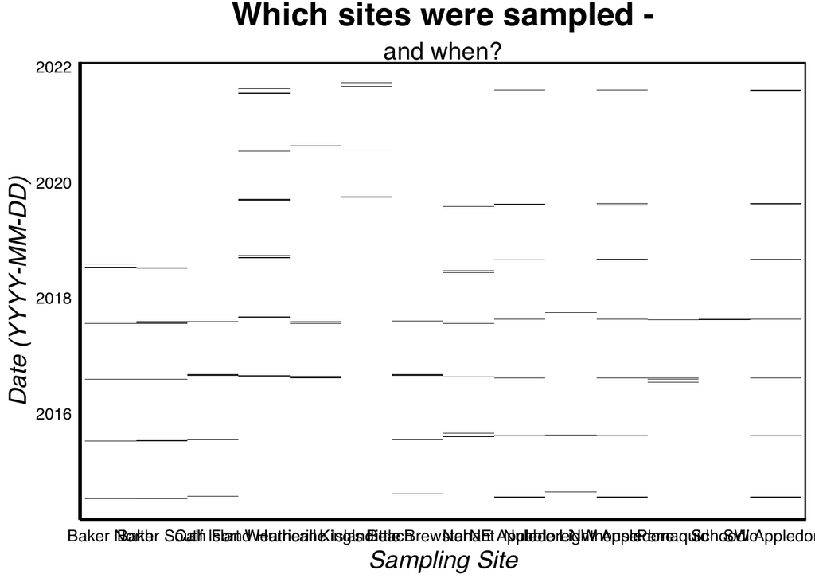

```r
kelp_sampledates <- ggplot(data = kelp) +
  labs(title = "Which sites were sampled -",
       subtitle = "and when?",
       x = "Sampling Site",
       y = "Date (YYYY-MM-DD)") +
  geom_tile(aes(x = SITE,
                y = SAMPLE_DATE)) +
  custom_theme()

kelp_sampledates
```

# *Part 4: Let’s look at some kelp!*

## *Part 4a:*

**This is a big unwieldy dataset. Let’s trim it down to the columns, YEAR, SITE, TRANSECT, PERCENT_COVER, and FAMILY, and SPECIES.**

```r
kelp <- kelp %>%
  select(YEAR, SITE, TRANSECT, PERCENT_COVER, FAMILY, SPECIES, SAMPLE_DATE)

kelp
```

```
##      YEAR              SITE            TRANSECT PERCENT_COVER
## 1    2014       Baker North                   1          2.50
## 2    2014       Baker North                   1          7.50
## 3    2014       Baker North                   1          2.50
## 4    2014       Baker North                   1         10.00
## 5    2014       Baker North                   1         21.25
## 6    2014       Baker North                   1          1.25
## 7    2014       Baker North                   1          1.25
## 8    2014       Baker North                   1         18.75
## 9    2014       Baker North                   1         21.25
## 10   2014       Baker North                   1          7.50
## 11   2014       Baker North                   1          8.75
## 12   2014       Baker North                   1          2.50
## 13   2014       Baker North                   1          1.25
## 14   2014       Baker North                   1          3.75
```

[output cut: 12431 more lines]

## *Part 4b:*

**Let’s make it even simpler. Trim the data down so the only species we are looking at are in the family “Laminariaceae”. After that, you can ditch the FAMILY column.**

```r
kelp <- kelp %>%
  filter(FAMILY == "Laminariaceae")

kelp
```

```
##     YEAR              SITE            TRANSECT PERCENT_COVER        FAMILY
## 1   2014       Baker North                   1         77.50 Laminariaceae
## 2   2014       Baker North                   2         86.25 Laminariaceae
## 3   2014       Baker North                   3         31.25 Laminariaceae
## 4   2014       Baker North                   3          7.50 Laminariaceae
## 5   2014       Baker North                   4         55.00 Laminariaceae
## 6   2014       Baker South                   3         36.25 Laminariaceae
## 7   2014       Baker South                   3         22.50 Laminariaceae
## 8   2014       Baker South                   4         32.50 Laminariaceae
## 9   2014       Baker South                   4         11.25 Laminariaceae
## 10  2014       Baker South                   1         35.00 Laminariaceae
## 11  2014       Baker South                   1         15.00 Laminariaceae
## 12  2014       Baker South                   2         41.25 Laminariaceae
## 13  2014       Baker South                   2          2.50 Laminariaceae
## 14  2014       Calf Island                   1          3.75 Laminariaceae
```

[output cut: 677 more lines]

## *Part 4c:*

**For each species is there only one measurement per species transect each year? Or do we need to worry…… Note, this is a common data check you should be doing if you have a large complex data set!**

```r
str(kelp) # stir the data to find out why
```

```
## 'data.frame':    345 obs. of  7 variables:
##  $ YEAR         : int  2014 2014 2014 2014 2014 2014 2014 2014 2014 2014 ...
##  $ SITE         : chr  "Baker North" "Baker North" "Baker North" "Baker North" ...
##  $ TRANSECT     : chr  "1" "2" "3" "3" ...
##  $ PERCENT_COVER: num  77.5 86.2 31.2 7.5 55 ...
##  $ FAMILY       : chr  "Laminariaceae" "Laminariaceae" "Laminariaceae" "Laminariaceae" ...
##  $ SPECIES      : chr  "Saccharina latissima" "Saccharina latissima" "Saccharina latissima" "Saccharina latissima" ...
##  $ SAMPLE_DATE  : Date, format: "2014-07-08" "2014-07-08" ...
```

I conclude that the measurements are likely from both adult and juveniles

## *Part 4d:*

**HAHA that was a trick. I knew there sometimes was more than one. That’s because some of these are measurements of juveniles and some are adults. OK - sum up the cover for each species on each transect so that we only have one measurement per species (adults and juveniles together!)**

```r
kelp_condense <- kelp %>%
  filter(FAMILY == "Laminariaceae") %>%
  select(-FAMILY) %>%
  group_by(YEAR, SPECIES, SITE, TRANSECT) %>%
  summarize(mean_transect_cover = mean(PERCENT_COVER,
                                       na.rm = TRUE))
kelp_condense
```

```
## # A tibble: 290 × 5
## # Groups:   YEAR, SPECIES, SITE [86]
##     YEAR SPECIES              SITE              TRANSECT mean_transect_cover
##    <int> <chr>                <chr>             <chr>                  <dbl>
##  1  2014 Laminaria digitata   Calf Island       1                       3.75
##  2  2014 Laminaria digitata   Calf Island       2                       3.75
##  3  2014 Laminaria digitata   Calf Island       3                       3.75
##  4  2014 Laminaria digitata   Calf Island       4                       2.5
##  5  2014 Laminaria digitata   Little Brewster   1                       1.25
##  6  2014 Laminaria digitata   Nubble Lighthouse 1                       3.75
##  7  2014 Saccharina latissima Baker North       1                      77.5
##  8  2014 Saccharina latissima Baker North       2                      86.2
##  9  2014 Saccharina latissima Baker North       3                      19.4
## 10  2014 Saccharina latissima Baker North       4                      55
## # … with 280 more rows
```

## *Part 4e:*

**Neat! Make a plot showing the timeseries of kelps at each site. You’ll want stat_summary() here. You might even need it twice because - note - stat_summary() has a geom argument where you can do things like “line”. What might that do? Check it out! Facet this plot by species, so we can see the trajectory of each. Feel free to gussy this plot up however you would like (or not). Do you notice anything? Comment!**

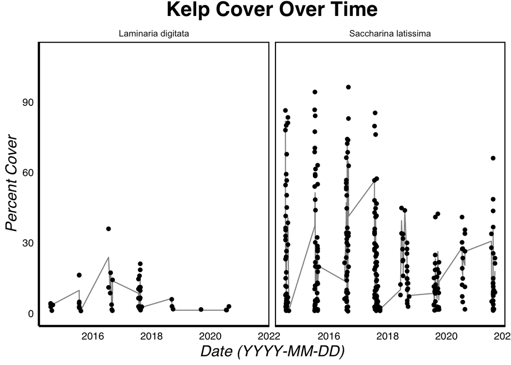

```r
kelp_timeseries <- ggplot(data = kelp,
                          aes(x = SAMPLE_DATE,
                              y = PERCENT_COVER)) + # plot with values
  labs(title = "Kelp Cover Over Time",
       x = "Date (YYYY-MM-DD)",
       y = "Percent Cover") + # labels
  stat_summary(aes(x = SAMPLE_DATE,
                   y = PERCENT_COVER),
               geom = "line",
               width = 0.5,
               size = 0.5,
               alpha = 0.5) + # stats to summarize + dimensions
  scale_y_continuous(limits=c(0, 110)) + # change y-axis limit
  custom_theme() +
  geom_jitter() + # adds jitter to allow plotting of overlapping data points
  facet_wrap(~ SPECIES) # splits plots into individ. plots per species
kelp_timeseries
```

The clearest takeaway is that percent cover is much higher for Saccharina latissima than for Laminaria digitata. It also looks like percent cover decreases over time for both species.

# *Part 5: Wide Relationships*

**Let’s look at the relationship between two of the species here. Lexi made me do this, I swear. She made me think about tradeoffs in our weekly meeting last week, so now you all have this problem.**

## *Part 5a:*

**If we want to look at the relationships between species, we need a wide data set. Use pivot_wider() to make species into columns with percent cover as your values. Note - be careful to fill in NAs as 0s.**

```r
kelp_overallcover_wide <- kelp_condense %>%
  pivot_wider(names_from = SPECIES,
              values_from = mean_transect_cover,
              values_fill = 0)

kelp_overallcover_wide
```

```
## # A tibble: 238 × 5
## # Groups:   YEAR, SITE [62]
##     YEAR SITE              TRANSECT `Laminaria digitata` `Saccharina latissima`
##    <int> <chr>             <chr>                   <dbl>                  <dbl>
##  1  2014 Calf Island       1                        3.75                  28.8
##  2  2014 Calf Island       2                        3.75                  28.1
##  3  2014 Calf Island       3                        3.75                  67.5
##  4  2014 Calf Island       4                        2.5                   23.8
##  5  2014 Little Brewster   1                        1.25                  28.8
##  6  2014 Nubble Lighthouse 1                        3.75                   1.25
##  7  2014 Baker North       1                        0                     77.5
##  8  2014 Baker North       2                        0                     86.2
##  9  2014 Baker North       3                        0                     19.4
## 10  2014 Baker North       4                        0                     55
## # … with 228 more rows
```

## *Part 5b:*

**Neat! Is there a relationship between Saccharina latissima and Laminaria digitata? Plot it. As a preview for 2 weeks from now, add a line to your ggplot stat_smooth(method = “lm”). Also, remember that you will need backticks ` around variables with spaces in them. What do you think? Feel free to use any other geoms or explore however you like here.**

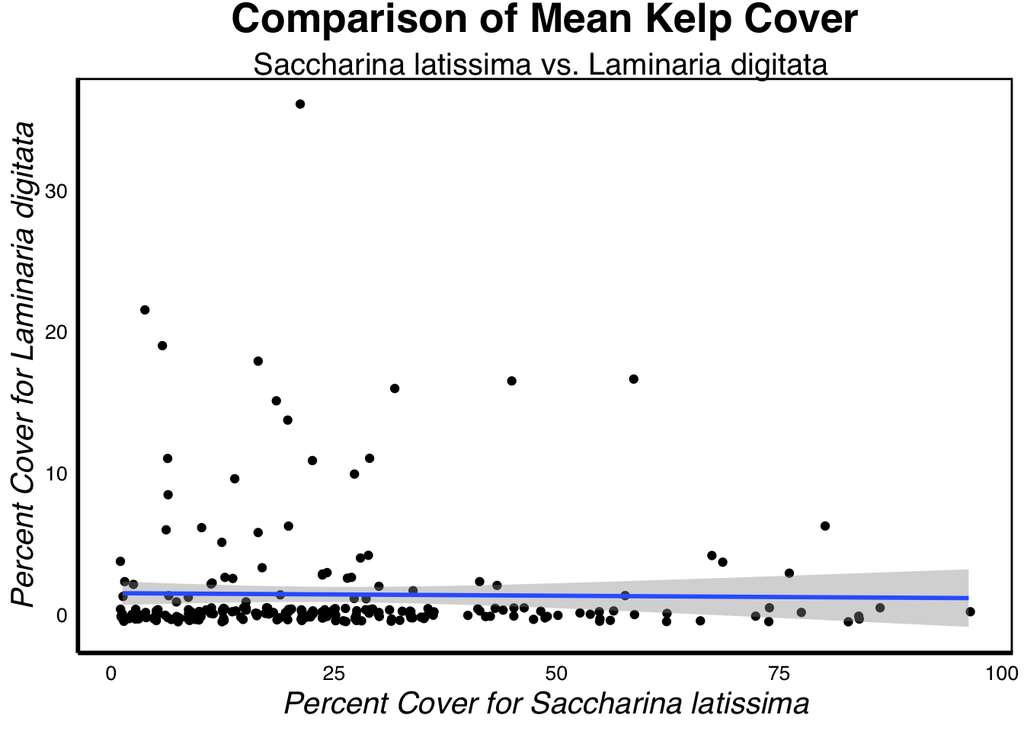

```r
kelp_overall_cover_plot <- ggplot(data = kelp_overallcover_wide,
                                  mapping = aes(x = `Saccharina latissima`,
                                                y = `Laminaria digitata`)) +
  geom_jitter() +
  stat_smooth(method = "lm") +
  custom_theme() +
  labs(title = "Comparison of Mean Kelp Cover",
       subtitle = "Saccharina latissima vs. Laminaria digitata ",
       x = "Percent Cover for Saccharina latissima",
       y = "Percent Cover for Laminaria digitata")

kelp_overall_cover_plot
```

## *Part 5c:*

**Hey, so, remember how we filled in a lot of 0s? Yeah, those weren’t in the original long data we plotted….. which means many of those lines from question 4e might be wrong! So let’s pivot this correct long data back wide and then remake the figure from 4e. Does it look different? Does it tell a different story?**

```r
kelp_condense_long <- kelp_overallcover_wide %>%
  pivot_longer(cols = -c(YEAR, SITE, TRANSECT),
               names_to = "SPECIES",
               values_to = "PERCENT_COVER")
kelp_condense_long
```

```
## # A tibble: 476 × 5
## # Groups:   YEAR, SITE [62]
##     YEAR SITE            TRANSECT SPECIES              PERCENT_COVER
##    <int> <chr>           <chr>    <chr>                        <dbl>
##  1  2014 Calf Island     1        Laminaria digitata            3.75
##  2  2014 Calf Island     1        Saccharina latissima         28.8
##  3  2014 Calf Island     2        Laminaria digitata            3.75
##  4  2014 Calf Island     2        Saccharina latissima         28.1
##  5  2014 Calf Island     3        Laminaria digitata            3.75
##  6  2014 Calf Island     3        Saccharina latissima         67.5
##  7  2014 Calf Island     4        Laminaria digitata            2.5
##  8  2014 Calf Island     4        Saccharina latissima         23.8
##  9  2014 Little Brewster 1        Laminaria digitata            1.25
## 10  2014 Little Brewster 1        Saccharina latissima         28.8
## # … with 466 more rows
```

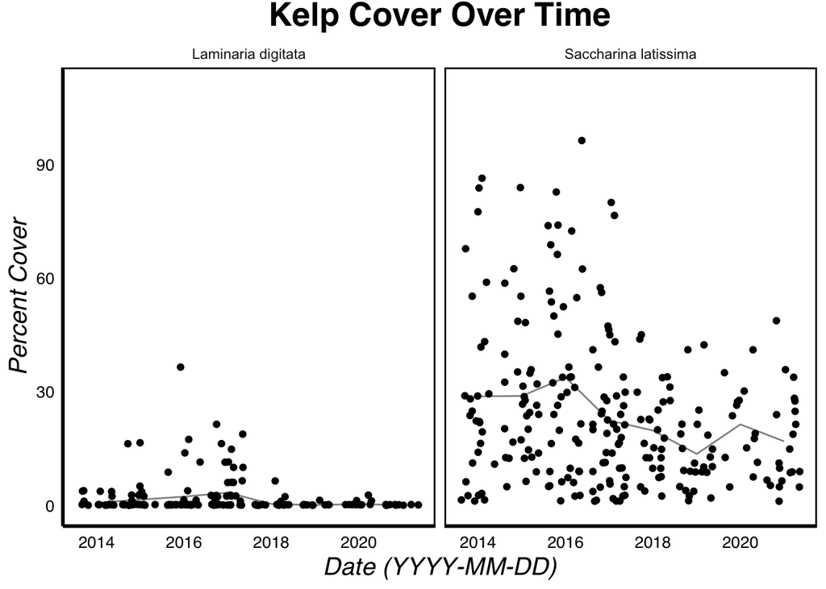

```r
kelp_timeseries_v2 <- ggplot(data = kelp_condense_long,
                             mapping = aes(x = YEAR,
                                           y = PERCENT_COVER)) +
  geom_jitter() +
  facet_wrap(vars(SPECIES)) +
  labs(title = "Kelp Cover Over Time",
       x = "Date (YYYY-MM-DD)",
       y = "Percent Cover") +
  stat_summary(aes(x = YEAR,
                   y = PERCENT_COVER),
               geom = "line",
               width = 0.5,
               size = 0.5,
               alpha = 0.5) +
  scale_y_continuous(limits=c(0, 110)) +
  custom_theme()
kelp_timeseries_v2
```

# *Meta Questions*

## *NOTE: I did not update my meta question responses after updating this homework on 2022-11-28.*

**How did it feel working with an unfamiliar dataset? What did you notice?**

1. It took some time to understand what the variables were and what was actually collected in this data set
2. For example, I had to do some research to understand what “percent cover” and “transect” mean
3. A key (or variable guide) would be really helpful with any dataset I work with

**Split-Apply-Combine is…. a way of life, really. Is this something you have dealt with previously in your life or work? How comfortable are you with this concept?**

I have dealt with the concept a bit without knowing the name for it It’s a bit of a logical pathway for problem solving I need to work on knowing when it is needed / when to apply it But I am comfortable with the use in this exercise

**When you’ve made datasets in the past, have they been wide, long, or something else? After this week and the Browman and Woo paper, what advice would you give to future you when making data?**

1. Though I am new to the terms “wide” and “long”, I have always made my datasets in the long format
2. This is because, conceptually, it is easier for me to understand data when it is recorded by observation, with each column being a different variable / measurement
3. When I have worked in Excel, I have ALWAYS made long datasets because filtering / sorting is really easy

**How much time did this take you, roughly? Again, I’m trying to keep track that these assignments aren’t killer, more than anything.**

1. This took me ~5 hours
2. I had a bit of a hard time understanding what was being asked in some questions (ex: 4d, 5c)
3. So I played around with these quite a bit to deduce the goal. In 4d, I just did double the work to address both ways I interpretted the question

**Please give yourself a weak/sufficient/strong assessment on this assigment. Feel free to comment on why.**

1. I will give myself a sufficient assessment
2. I was able to figure out how to complete the exercises
3. But, on 5c I chose to take a different solution that seemed easier. This might not have addressed the goal of the exercise but it saved a lot of time and effort
4. I understand the concepts, but it took me quite a bit of effort and troubleshooting to apply them here
5. I definitely need repeated practice to be able to do this without referencing the internet, my past work, class resources, etc.